# Analysis of Caribou Movements with the TuktuTools R Package

Ophélie Couriot and Eliezer Gurarie

5/5/2023

# Introduction

During this workshop, we will demonstrate the `TuktuTools` package, which has been developed for studying Tuktu (caribou) movement ecology and spatial patterns.

To date, this package contains functions that prep and filter movement data:

- `process_moveNWT` - processes data from Movebank;
- `removeoutliers` - flags fixes considered as *outliers*;
- `prepData` - prepares and filters data to a specific period of time and/or a minimum number of fixes per day;
- `scan_tracks` - visualizes individual paths through time

The package also contains functions that analyze spatial patterns, including: - `getSpeed` - computes individual movement rates, displacements, speeds; - `getDailyMean` - estimates individual mean daily location (i.e., the mean x and y coordinates of all the daily locations for a given individual); - `getLoCoH` and `getKernelUD` - estimates ranging areas with Local Convex Hulls (LoCoH) or Kernel Utilization Distributions (KUD); - `getPairwiseDistance` and `getPairwiseOverlap` - estimates daily pairwise distance or pairwise overlap between pairs of individuals; - `estimateCalving` - estimates calving status (non-calving or calving, calving with survival or calving with calf death), calving timing, and calving location for given females, using movement rate; - `estimateMigration_stan` - estimates population-level migration timing using STAN

The package contains the following data:

- `caribou` - anonymized movement data for 4 individual Barren-ground caribou;
- `simulated_migrations` - simulated movement tracks for 18 individuals

Most of the functions in this package have been developed to handle simple features. Simple features, supported by the package `sf`, are georeferenced spatial objects, allowing to easily project data on a map, transform the projection and manipulate the data (e.g., link points into lines, union polygons, etc.).

# Installation

To install the current version of this package in R:

```r
install.packages("devtools")
devtools::install_github("ocouriot/TuktuTools", build_vignettes = TRUE)
```

# Chapter 1: Data and Vizualisation

## Data

The `TuktuTools` package contains real movement data from 4 caribou individuals, which have been anonymized. The package also contains data of 18 simulated tracks of caribou, during the spring migration.

```r
require(TuktuTools)
data(package = 'TuktuTools')
```

## Explore data

The `caribou` dataset contains real movement data for 4 caribou individuals. It contains the `ID` of the individuals, the `sex`, as well as the `Time` and `Lon`,`Lat` (in WGS 84, epsg: 4326) and `x`,`y` (UTM zone 10N, epsg: 32610) coordinates of their GPS locations.

```r
data(caribou)
head(caribou)
```

```
##       ID sex                Time Year       Lon      Lat         x       y
## 1 Dancer   f 2002-04-01 00:00:00 2002 -133.8427 62.77028 -51589.97 7006600
## 2 Dancer   f 2002-04-01 08:00:00 2002 -133.8394 62.76716 -51480.43 7006228
## 3 Dancer   f 2002-04-01 16:00:00 2002 -133.8453 62.77767 -51584.51 7007437
## 4 Dancer   f 2002-04-02 00:00:00 2002 -133.8643 62.80010 -52121.93 7010074
## 5 Dancer   f 2002-04-02 08:00:00 2002 -133.8621 62.79918 -52024.50 7009953
## 6 Dancer   f 2002-04-02 16:00:00 2002 -133.8625 62.80007 -52030.49 7010055
```

### Number of individuals and sex

```r
unique(caribou$ID)
```

```
## [1] Dancer  Prancer Vixen   Comet
## Levels: Dancer Prancer Vixen Comet
```

There are 4 individuals: Dancer, Prancer, Vixen and Comet.

Their sex:

```r
with(caribou, unique(data.frame(ID, sex)))
```

```
##            ID sex
## 1      Dancer   f
## 8564  Prancer   f
## 11195   Vixen   f
## 13715   Comet   f
```

They are all females.

### What is the range and duration of their monitoring?

What are the years each individual was monitored?

```r
with(caribou, unique(data.frame(ID, Year)))
```

```
##            ID Year
## 1      Dancer 2002
## 2469   Dancer 2003
## 4240   Dancer 2004
## 8356   Dancer 2005
## 8564  Prancer 2014
## 9369  Prancer 2015
## 10464 Prancer 2016
## 11195   Vixen 2007
## 12019   Vixen 2008
## 13122   Vixen 2009
## 13715   Comet 2006
## 15390   Comet 2007
## 17799   Comet 2008
```

One approach is to use plyr::ddply commands. This function allows you apply functions to different groups (subsets) of a data set. Here’s an example:

```r
caribou %>% ddply("ID", plyr::summarize,
                 start= min(Time), end = max(Time)) %>%  # get the first and last locations time for each individual
  mutate(duration = difftime(end, start, units = "days")) # calculate duration
```

```
##        ID               start                 end       duration
## 1  Dancer 2002-04-01 00:00:00 2005-03-11 00:00:00 1075.0000 days
## 2 Prancer 2014-04-04 00:01:00 2016-09-02 08:00:00  882.3326 days
## 3   Vixen 2007-04-01 00:00:00 2009-08-01 16:00:00  853.6667 days
## 4   Comet 2006-04-01 00:00:00 2008-04-01 16:00:00  731.6667 days
```

We can visualize the monitoring duration for each individual, on a plot, by extracting the start date and the end date of the monitoring for each individual.

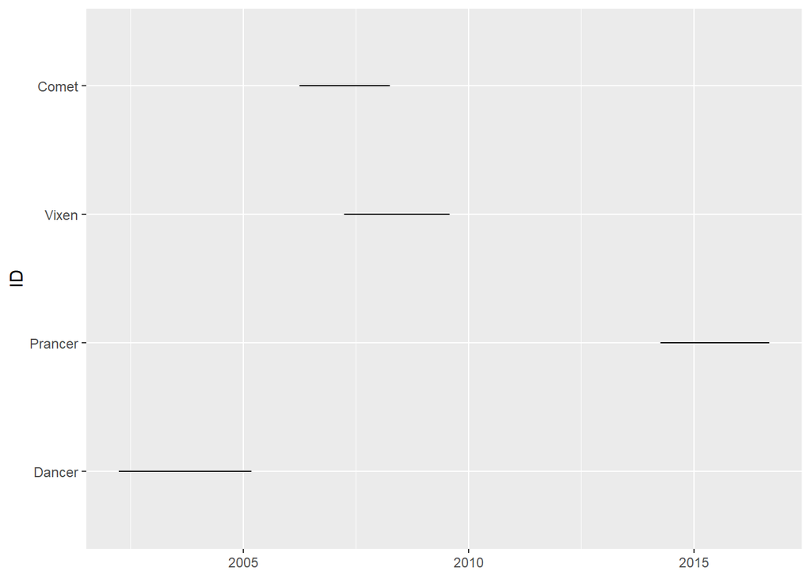

```r
n.summary <- caribou %>% group_by(ID) %>%
  summarize(start = min(Time), end = max(Time)) %>% # get the first and last locations time
  mutate(ID = factor(ID, levels = as.character(ID)))

ggplot(n.summary, aes(y = ID, xmin = start, xmax = end)) +
    geom_linerange()
```

When there are multiple individuals (sometimes hundreds), It may make more sense to sort the individuals not alphabetically, but by the time of capture. Here’s an approach:

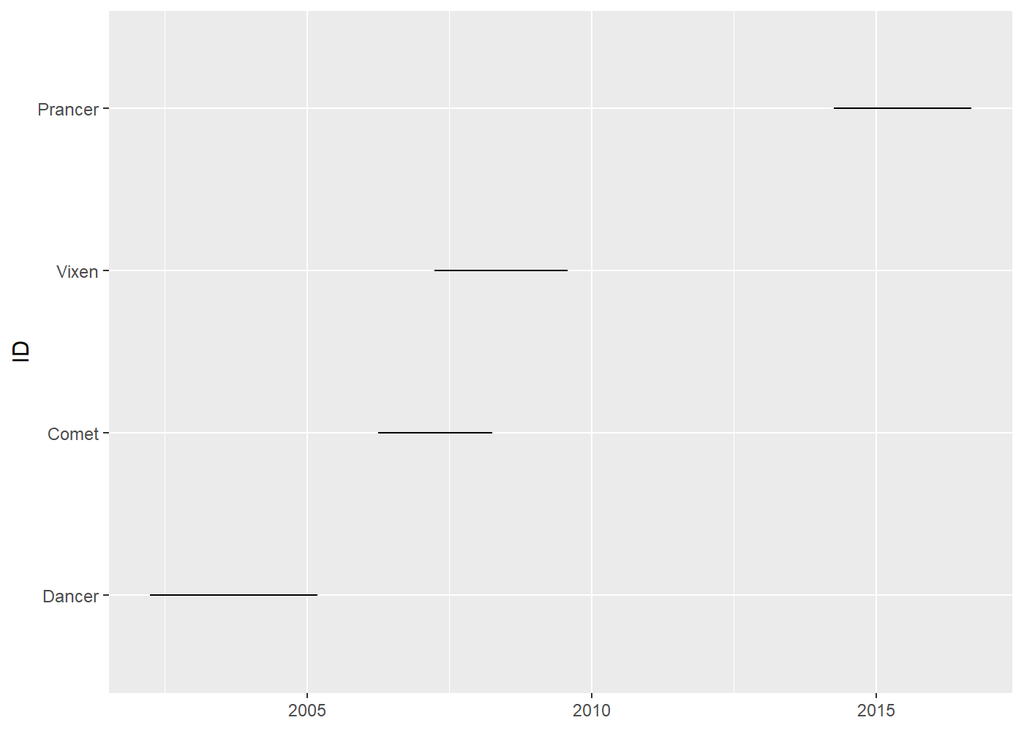

```r
n.summary <- caribou %>% group_by(ID) %>%
  summarize(start = min(Time), end = max(Time)) %>%
  arrange(start) %>% # arrange chronologically instead of by ID
  mutate(ID = factor(ID, levels = as.character(ID)))

ggplot(n.summary, aes(y = ID, xmin = start, xmax = end)) +
    geom_linerange()
```

On those figures each line represents the duration of the monitoring (x axis) for a given individual (y axis).

### What is the fix rate?

The fix rate, or the time lag between successive locations, can be extracted by using the difftime() function on the Time column. Again, this function needs to be applied to each individual separately. Here, we are subsetting the data set per ID, and applying a function which is adding a column difftime to each subset. Note that since the vector of time difference is smaller than the vector of time, we add a missing value at the beginning of each vector, for each value to represent the difference in time to the previous location.

```r
caribou <- caribou %>% ddply("ID", mutate,
        dtime = c(NA, difftime(Time[-1], Time[-length(Time)], units = "hours"))) # calculate time between successive locations
head(caribou)
```

```
##       ID sex                Time Year       Lon      Lat         x       y
## 1 Dancer   f 2002-04-01 00:00:00 2002 -133.8427 62.77028 -51589.97 7006600
## 2 Dancer   f 2002-04-01 08:00:00 2002 -133.8394 62.76716 -51480.43 7006228
## 3 Dancer   f 2002-04-01 16:00:00 2002 -133.8453 62.77767 -51584.51 7007437
## 4 Dancer   f 2002-04-02 00:00:00 2002 -133.8643 62.80010 -52121.93 7010074
## 5 Dancer   f 2002-04-02 08:00:00 2002 -133.8621 62.79918 -52024.50 7009953
## 6 Dancer   f 2002-04-02 16:00:00 2002 -133.8625 62.80007 -52030.49 7010055
##   dtime
## 1    NA
## 2     8
## 3     8
## 4     8
## 5     8
## 6     8
```

What are the statistics (min, max, mean, median, …) of this fix rate?

```r
caribou$dtime %>% summary
```

```
##      Min.   1st Qu.    Median      Mean   3rd Qu.      Max.      NA's
##   0.01667   1.00000   7.98333   4.70526   8.00000 160.00000         4
```

Which animal is it and when did it occur?

```r
# which row corresponds to the big fix rate
which(caribou$dtime > 159 & is.na(caribou$dtime) == FALSE)
```

```
## [1] 13428
```

```r
# look at the rows around the one with a big fix rate
caribou[13426:13430,]
```

```
##          ID sex                Time Year       Lon      Lat         x       y
## 13426 Vixen   f 2009-04-11 08:00:00 2009 -133.6903 63.23813 -35214.68 7056887
## 13427 Vixen   f 2009-04-11 16:00:00 2009 -133.6960 63.23736 -35510.67 7056849
## 13428 Vixen   f 2009-04-18 08:00:00 2009 -133.6482 63.31229 -31746.28 7064711
## 13429 Vixen   f 2009-04-18 16:00:00 2009 -133.6473 63.31272 -31695.79 7064751
## 13430 Vixen   f 2009-04-19 00:01:00 2009 -133.6484 63.31315 -31738.92 7064807
##            dtime
## 13426   8.000000
## 13427   8.000000
## 13428 160.000000
## 13429   8.000000
## 13430   8.016667
```

Vixen has missing data between April 11, 2009 and April 18, 2009.

## Prepare and filter data

Now that we know what the data look like, we can prepare and filter them depending on what we are examining. Later in this workshop, we will identify calving timing and calving location for each female. Barren-ground caribou calve between mid-May to mid-June. Studies examining calving dates considered data between May 19 and July 7 (@cameronMovementbasedMethodsInfer2018; @couriotContinentalSynchronyLocal2023). So let’s filter and prepare the data during this period for each individual.

The `prepData` function, from the `TuktuTools` package, allows to filter data for a defined period, using a start date and an end date, irrespective of the year. This function also allows setting an average minimum number of fixes (relocations) per day, which exclude tracks for individuals having fewer daily fixes than this threshold. Finally, it allows defining a maximum number of successive days missing data. The two last parameters are optional. This function returns a data frame filtered as desired, and indicates the number of individual-year that have been excluded.

```r
caribou_prepped <- prepData(caribou, start = "05-19", end = "07-07")
```

```
## Period clipped to 05-19 - 07-07
## Number of excluded individuals-years: 2
```

2 individual-year have been excluded. We can compare the individual-year with our original dataset, to know which individuals have been lost.

```r
setdiff(unique((caribou %>% mutate(ID_year = paste(ID, Year, sep = ":")))$ID_year),
        unique((caribou_prepped %>% mutate(ID_year = paste(ID, Year, sep = ":")))$ID_year))
```

```
## [1] "Dancer:2005" "Comet:2008"
```

[figure not shown]

Looking back at this figure, we see it is because those two individuals were not monitored during the calving period those years.

## Visualizing data

`TuktuTools` contains a function to visualize animal tracks: `scan_tracks`. It is helpful to see individuals’ trajectories, as well as examine the variation of their x and y locations through time. Note: to use this function, X,Y columns must be capitalized.

### Using `scan_track`

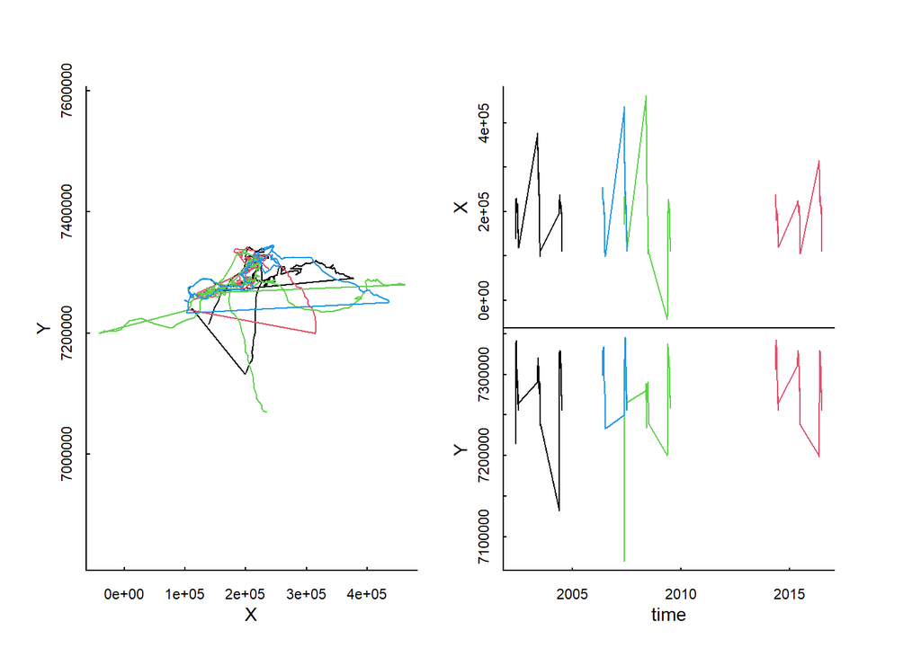

```r
scan_tracks(caribou_prepped %>% mutate(X=x, Y=y))
```

As individuals are not monitored the same years (and some of them have several years of monitoring), it is difficult to examine the variation of x and y coordinates through time. We can thus apply this function per individual and per year:

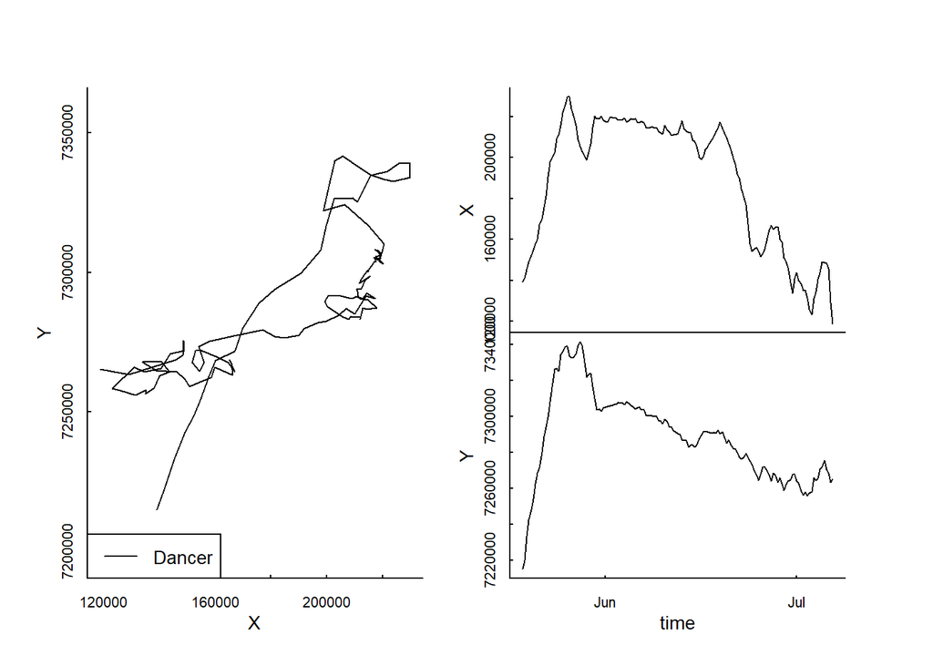

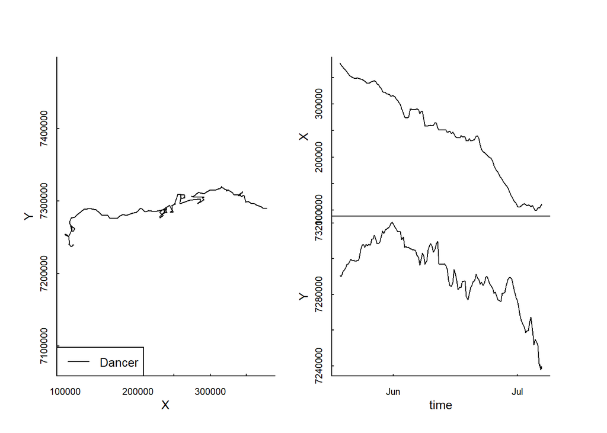

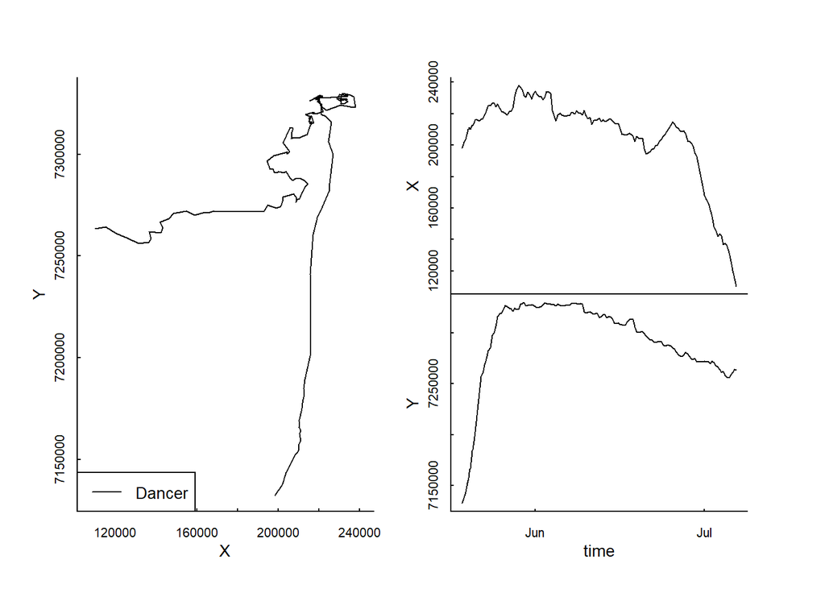

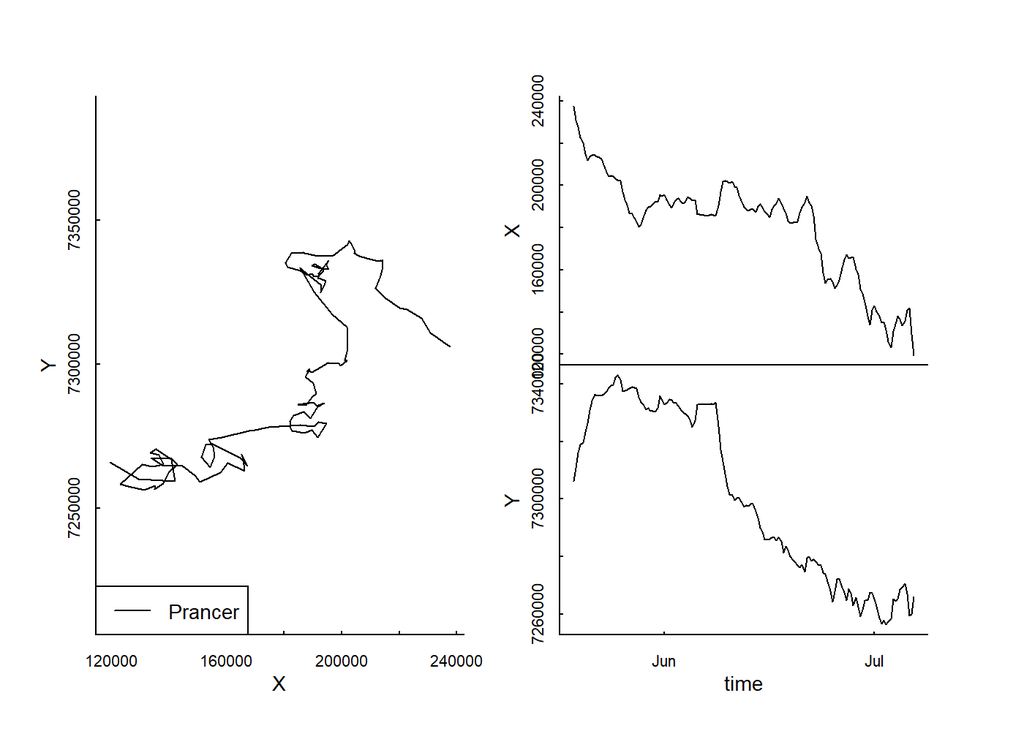

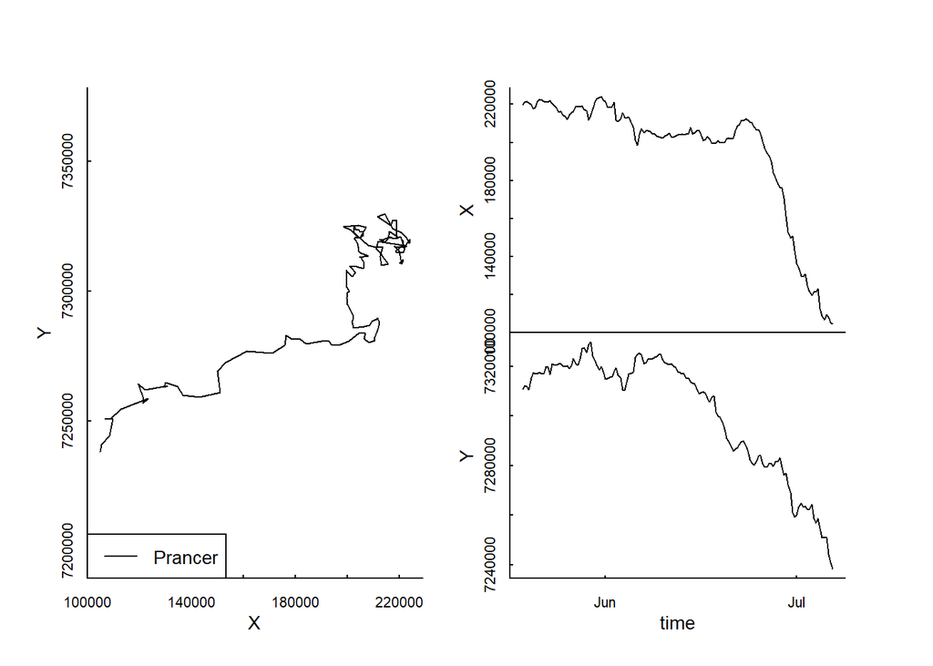

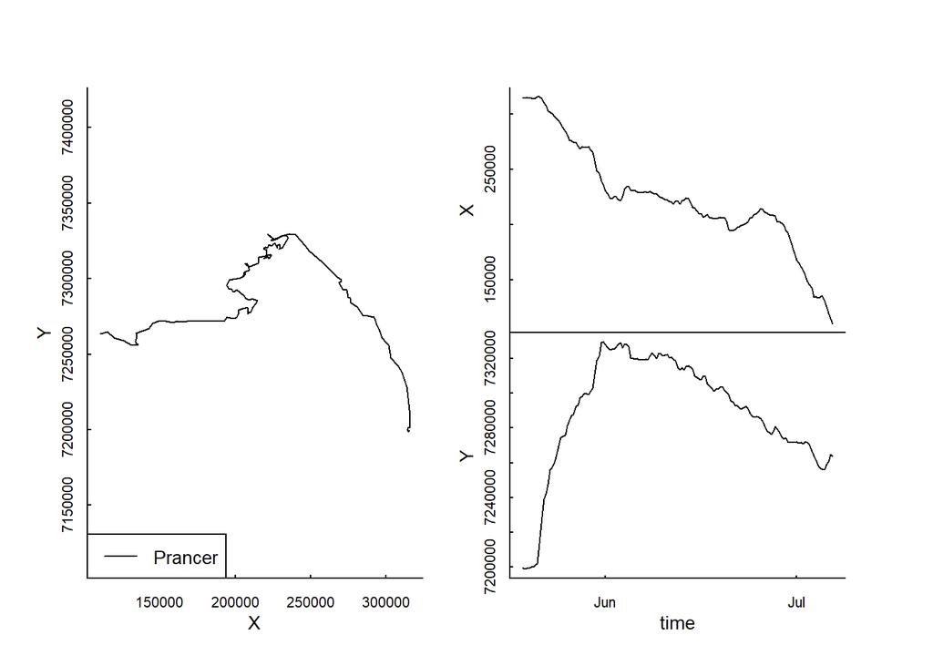

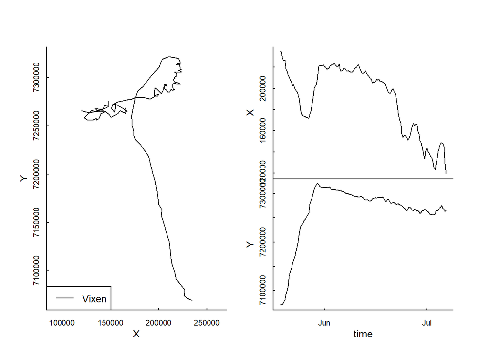

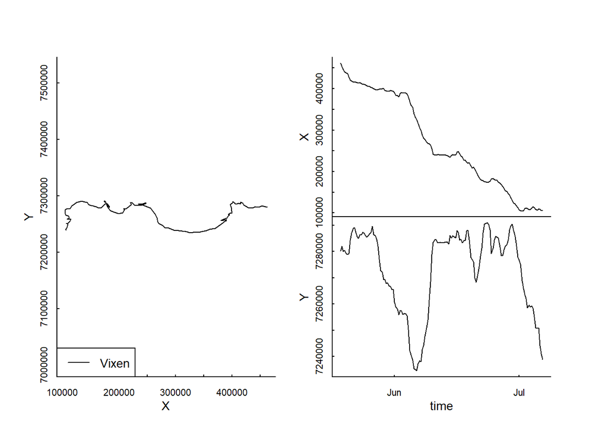

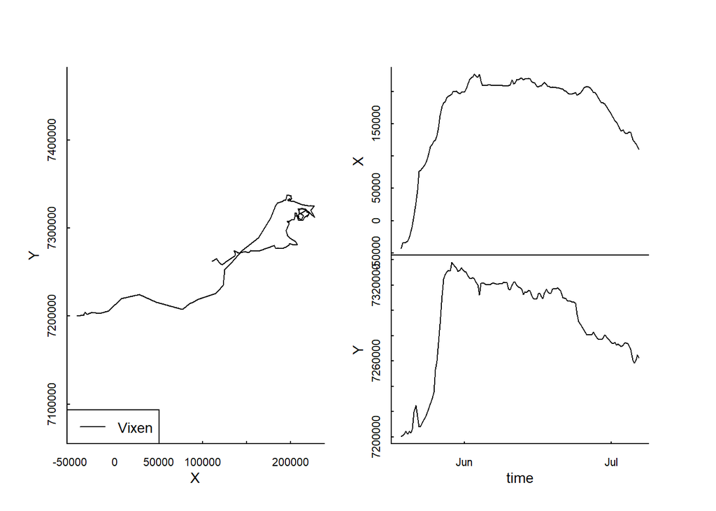

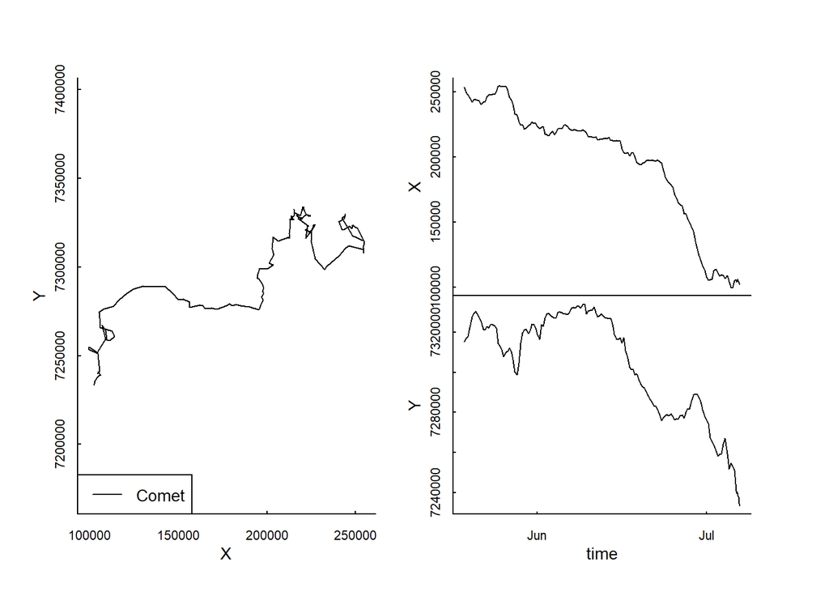

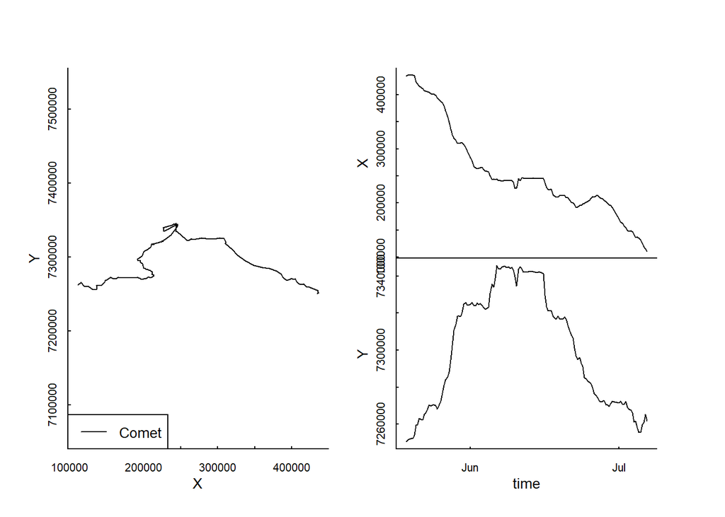

```
## data frame with 0 columns and 0 rows
```

```r
caribou_prepped %>% mutate(X=x, Y=y) %>% ddply(c("ID", "Year"), scan_tracks, legend = TRUE)
```

### Visualization on a map

We can also visualize the trajectories on a map, using the package `basemap`, which allows to download a base map as a raster. Note that it takes coordinates in WGS84 (crs = 4326), and return a map with a different crs (crs = 3857).

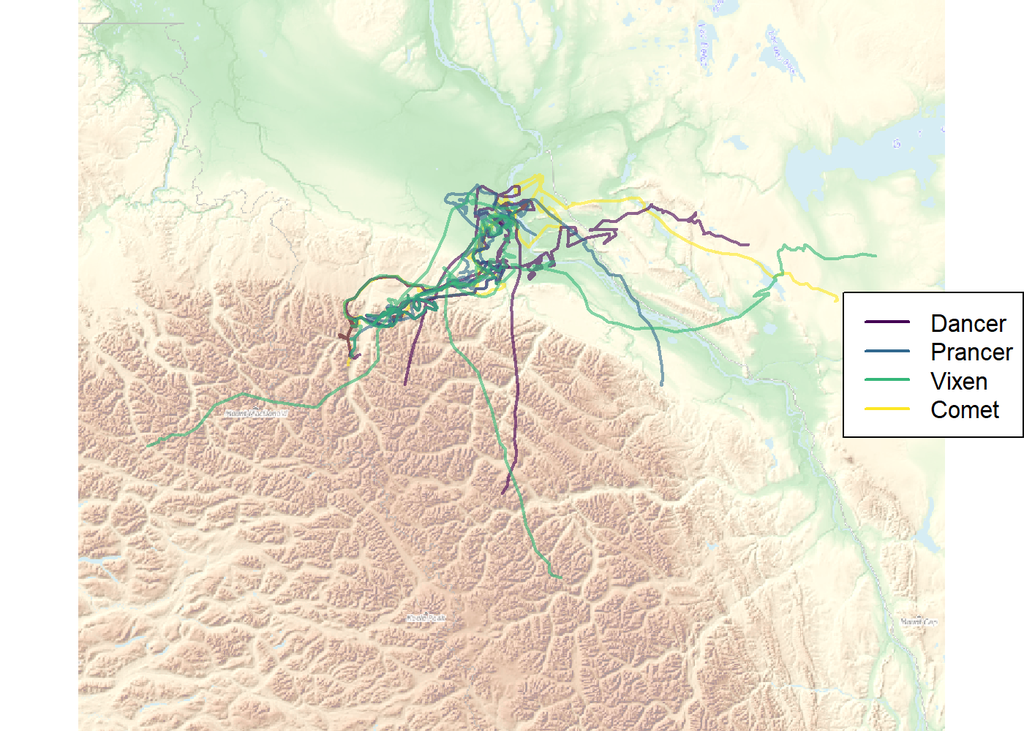

```r
# transform the dataset in a simple feature object (projected object)
caribou_sf <- caribou_prepped %>% st_as_sf(coords=c("Lon", "Lat"), crs = 4326)

# download the map using the basemaps::basemap_raster
bbox <- st_bbox(caribou_sf) + c(-1,-1,1,1)
map <- basemaps::basemap_raster(ext = bbox, map_service = "osm", map_type = "topographic", map_res = 2)

# create lines for each individual dand year
# transform in crs: 3857 (same as the map for plotting)
lines <- caribou_sf %>%
  group_by(ID, Year) %>% arrange(Time) %>%
  summarize(do_union = FALSE) %>%
  st_cast("LINESTRING") %>% st_transform(3857)

# add colors using viridis
library(viridis)
cols <- data.frame(ID = unique(caribou_sf$ID),
                   cols = viridis(length(unique(caribou_sf$ID))))
lines <- lines %>% merge(cols, by = "ID")

# Draw the map and add the individuals tracks with legend
raster::plotRGB(map, asp = 1, alpha = 100)
plot(st_geometry(lines), add = TRUE, col = alpha(lines$cols, alpha = .6), lwd = 2)
legend("right", legend = cols$ID,
     col = cols$cols,
     lwd = 2,  ncol=1)
```

### Using Mapview

The `mapview` package is really handy, as it creates interactive map, using simple feature objects.

```r
mapview::mapview(lines, zcol = "ID")
```

[interactive chart not shown]

We can zoom in and out on the map, as well as click on the lines to have its information.

# Chapter 2: Basic analysis using TuktuTools

The `TuktuTools` packages offers a range of functions allowing to easily summarize data and estimate movement rate and range distributions.

## Get the daily mean location

The `getDailyMean` function is a function which takes any large movement dataset and return the daily mean locations for each individual for each day for each year of observations.

Let’s calculate the daily mean locations for individuals during the calving period.

```r
caribou_daily_mean <- getDailyMean(caribou_prepped)
head(caribou_daily_mean)
```

```
##       ID Year yday       Lon      Lat        x       y    dtime sex
## 1 Dancer 2002  139 -130.5903 64.93708 141896.0 7222972 7.333333   f
## 2 Dancer 2002  140 -130.4412 65.17436 152022.0 7248435 8.000000   f
## 3 Dancer 2002  141 -130.2851 65.35544 161623.4 7267659 8.000000   f
## 4 Dancer 2002  142 -130.0343 65.54760 175623.2 7287645 8.000000   f
## 5 Dancer 2002  143 -129.6419 65.74962 196039.9 7308092 8.000000   f
## 6 Dancer 2002  144 -129.4325 65.92092 207557.8 7326106 8.000000   f
##                  Time
## 1 2002-05-19 08:00:00
## 2 2002-05-20 08:00:00
## 3 2002-05-21 08:00:00
## 4 2002-05-22 08:00:00
## 5 2002-05-23 08:00:00
## 6 2002-05-24 08:00:00
```

This function becomes handy when we are dealing with very large dataset, to homogenize data, by having one location per day for each individual, and do further analyses not requiring a fine fix rate.

## Get the daily movement rate

The package contains a function which is calculating the movement rate between successive locations for each individual: `getSpeed`.

Calculating the movement rate between successive daily locations. Note that this function calculate movement rate for each individual separately, but if individuals are monitored several years with a break in between (as in this case, since we considered only the calving period), it is essential to apply this function to each individual and year separately!

```r
daily_mr <- caribou_daily_mean %>%
  ddply(c("ID", "Year"), getSpeed)
head(daily_mr)
```

```
##       ID Year yday       Lon      Lat        x       y    dtime sex
## 1 Dancer 2002  139 -130.5903 64.93708 141896.0 7222972 7.333333   f
## 2 Dancer 2002  140 -130.4412 65.17436 152022.0 7248435 8.000000   f
## 3 Dancer 2002  141 -130.2851 65.35544 161623.4 7267659 8.000000   f
## 4 Dancer 2002  142 -130.0343 65.54760 175623.2 7287645 8.000000   f
## 5 Dancer 2002  143 -129.6419 65.74962 196039.9 7308092 8.000000   f
## 6 Dancer 2002  144 -129.4325 65.92092 207557.8 7326106 8.000000   f
##                  Time               z dt       sl dhours     speed
## 1 2002-05-19 08:00:00 141896+7222972i NA       NA      0        NA
## 2 2002-05-20 08:00:00 152022+7248435i 24 27402.36     24 1141.7651
## 3 2002-05-21 08:00:00 161623+7267659i 24 21489.07     48  895.3780
## 4 2002-05-22 08:00:00 175623+7287645i 24 24401.46     72 1016.7275
## 5 2002-05-23 08:00:00 196040+7308092i 24 28894.71     96 1203.9461
## 6 2002-05-24 08:00:00 207558+7326106i 24 21381.66    120  890.9024
```

We can visualize the movement rate of each individual through time. To have all the individuals on the same figure, we add a column `doy` (i.e, day of year). We also need to create a column for each ID-Year, as some individuals have been monitored several years.

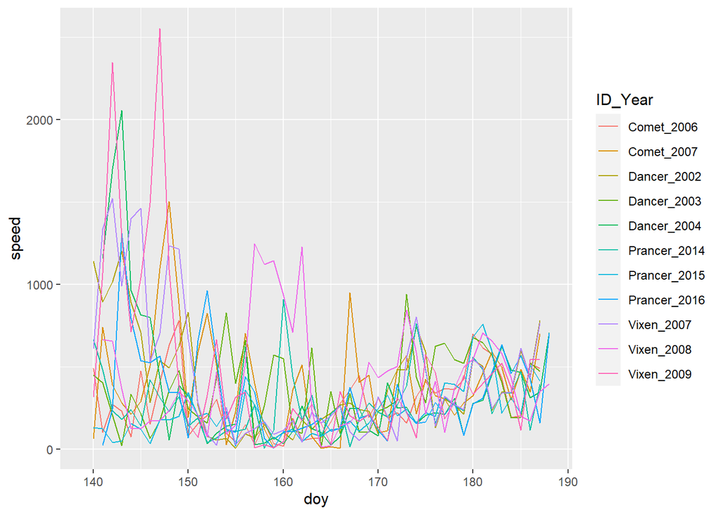

```r
daily_mr <- daily_mr %>% mutate(doy = yday(Time), ID_Year = as.factor(paste(ID, Year, sep = "_")))
ggplot(data = daily_mr, aes(x = doy, y = speed, group = ID_Year, colour = ID_Year)) + geom_line()
```

## Get Kernel UD

In the `TuktuTools` package, we added a function that allows to easily compute kernel utilization distributions, in one line of code: `getKernelUD`. This function uses the function `kernelUD` from the `adehabitatHR` package, and thus has the same parameters found in the `kernelUD` function.

```r
individuals_kernel <- caribou_daily_mean %>% st_as_sf(coords=c("x", "y"), crs = 32610) %>%
  ddply(c("ID","Year"), getKernelUD, extent = 10) %>% st_as_sf(crs = 32610)
head(individuals_kernel)
```

```
## Simple feature collection with 6 features and 4 fields
## Geometry type: POLYGON
## Dimension:     XY
## Bounding box:  xmin: 51181.27 ymin: 7125049 xmax: 419304.2 ymax: 7385712
## Projected CRS: WGS 84 / UTM zone 10N
##        ID Year        id        area                       geometry
## 1  Dancer 2002 homerange 12188602525 POLYGON ((113142.5 7241814,...
## 2  Dancer 2003 homerange 48483706527 POLYGON ((79139.69 7205536,...
## 3  Dancer 2004 homerange 21657374195 POLYGON ((107241.3 7233415,...
## 4 Prancer 2014 homerange 11318075672 POLYGON ((106989.8 7258670,...
## 5 Prancer 2015 homerange 11568424749 POLYGON ((96700.08 7229964,...
## 6 Prancer 2016 homerange 29417123198 POLYGON ((99316.73 7241306,...
```

```r
# visualize
mapview::mapview(individuals_kernel, zcol = "ID")
```

[interactive chart not shown]

## Get LoCoH

We also added the `getLoCoH` function, which allows to compute Local Convex Hull (LoCoH), which is known to perform better than parametric kernel methods, in the context of estimating the size of HRs and delineating geological and ecological features in home ranges. The LoCoH method is both a generalization of the minimum convex polygon (MCP) method and essentially a non-parametric kernel method. LoCoH applies the MCP construction to a subset of data localized in space, and the local convex polygon (i.e. local hull) is constructed using a specific number of nearest neighbors (nn) of each data point, thereby producing a set of nonparametric kernels whose union is the UD. One adavntage of using LoCoH is that this method allows to consider avoided areas (or holes) in ranges.

```r
individuals_locoh <- caribou_daily_mean %>% st_as_sf(coords=c("x", "y"), crs = 32610) %>%
  ddply(c("ID","Year"), getLoCoH) %>% st_as_sf(crs = 32610)
```

[output not shown]

[output not shown]

[output not shown]

[output not shown]

[output not shown]

[output not shown]

[output not shown]

[output not shown]

[output not shown]

[output not shown]

[output not shown]

```r
head(individuals_locoh)
```

```
## Simple feature collection with 6 features and 9 fields
## Geometry type: GEOMETRY
## Dimension:     XY
## Bounding box:  xmin: 106130 ymin: 7138079 xmax: 373624 ymax: 7342216
## Projected CRS: WGS 84 / UTM zone 10N
##        ID Year iso.level       area edge.len nep       ptp     hm.val num.hulls
## 1  Dancer 2002      0.95 2216966987 315097.9  48 0.9795918  518562640        42
## 2  Dancer 2003      0.95 3327872648 573612.3  47 0.9591837 1282196041        40
## 3  Dancer 2004      0.95 6646553994 528376.4  48 1.0000000 4510053399        46
## 4 Prancer 2014      0.95  999715460 257245.0  47 0.9591837  277318613        33
## 5 Prancer 2015      0.95 2006656546 321917.5  49 1.0000000  889874581        43
## 6 Prancer 2016      0.95 3114656310 568766.5  47 0.9791667 1039205812        40
##                         geometry
## 1 POLYGON ((219025.7 7304028,...
## 2 POLYGON ((261294.6 7307974,...
## 3 POLYGON ((218654.9 7327049,...
## 4 MULTIPOLYGON (((190705.4 73...
## 5 POLYGON ((203329.4 7324986,...
## 6 POLYGON ((223395.4 7327992,...
```

```r
# visualize
mapview::mapview(individuals_locoh, zcol = "ID")
```

[interactive chart not shown]

The default number of nearest neighbors in the `getLoCoH` function as been set to 10. However, it is worth noting that the resulting area is sensitive to the number of nearest neighbors chosen when computing the Local Convex Hulls (LoCoH). We recommend trying different numbers of nearest neighbors to compute ranges.

Let’s try here with a bigger number of nearest neighbors:

```r
individuals_locoh2 <- caribou_daily_mean %>% st_as_sf(coords=c("x", "y"), crs = 32610) %>%
  ddply(c("ID","Year"), getLoCoH, nn = 30) %>% st_as_sf(crs = 32610)
```

[output not shown]

[output not shown]

[output not shown]

[output not shown]

[output not shown]

[output not shown]

[output not shown]

[output not shown]

[output not shown]

[output not shown]

[output not shown]

```r
head(individuals_locoh2)
```

```
## Simple feature collection with 6 features and 9 fields
## Geometry type: POLYGON
## Dimension:     XY
## Bounding box:  xmin: 101054.8 ymin: 7199165 xmax: 373624 ymax: 7342216
## Projected CRS: WGS 84 / UTM zone 10N
##        ID Year iso.level       area edge.len nep       ptp     hm.val num.hulls
## 1  Dancer 2002      0.95 3435319719 287122.1  48 0.9795918 2228207540        33
## 2  Dancer 2003      0.95 7696562183 590162.2  49 1.0000000 4976889697        38
## 3  Dancer 2004      0.95 5795861390 390309.7  46 0.9583333 4496207575        41
## 4 Prancer 2014      0.95 3705011389 274058.1  47 0.9591837 2327582610        31
## 5 Prancer 2015      0.95 2847761237 290603.4  48 0.9795918 2545937038        42
## 6 Prancer 2016      0.95 8546771254 525972.7  48 1.0000000 6014727135        42
##                         geometry
## 1 POLYGON ((210809.3 7283850,...
## 2 POLYGON ((343640.7 7311865,...
## 3 POLYGON ((219927.8 7328265,...
## 4 POLYGON ((186191.4 7338714,...
## 5 POLYGON ((220916.8 7311578,...
## 6 POLYGON ((233972.4 7327925,...
```

```r
#  visualize
mapview::mapview(individuals_locoh2, zcol = "ID")
```

[interactive chart not shown]

We can see that the more nearest neighbors, the less sensitive to avoided areas the method is.

# Chapter 3: Estimating parturition time and location

To estimate parturition time and location, we refined the “individual-based method” (IBM) developed by DeMars et al (2013) to infer calving status. The method is detailed in the `estimating_parturition` vignette of the `TuktuTools` package.